# Plant_1_Linreg_Daily

tanchuanxin

11/1/2021

# Setup

We will perform the necessary imports, and change the working directory based on the user

```r
knitr::opts_chunk$set(echo = TRUE)
library(data.table)
```

```r
library(rpart)
library(rpart.plot)
library(car)
library(corrplot)
library(tidyverse)
library(caTools)
library(ggplot2)
library(lubridate)
library(TTR)
library(tsbox)
# setwd("C:/Users/matth/Desktop/Course Materials for Stu/AY21 Team Assignment and Project")
setwd("C:/Users/user/Documents/Github/project-MAI") # chuanxin's wd
set.seed(2021)
seed = 2021
# load dataset
plant_1.dt <- fread("Plant_1_Data.csv")

# convert some features into factors where relevant
plant_1.dt$SOURCE_KEY <- factor(plant_1.dt$SOURCE_KEY)
plant_1.dt$DOTW <- factor(plant_1.dt$DOTW)
plant_1.dt$TIME <- factor(plant_1.dt$TIME)
plant_1.dt$DATE <- factor(plant_1.dt$DATE)

head(plant_1.dt)
```

```
##          DATE  TIME PLANT_ID      SOURCE_KEY DC_POWER AC_POWER DAILY_YIELD
## 1: 2020-05-16 06:15  4135001 1BY6WEcLGh8j5v7 309.0000 29.86250    3.875000
## 2: 2020-05-16 06:15  4135001 1IF53ai7Xc0U56Y 353.1429 34.15714    3.714286
## 3: 2020-05-16 06:15  4135001 3PZuoBAID5Wc2HD 346.5714 33.48571    3.714286
## 4: 2020-05-16 06:15  4135001 7JYdWkrLSPkdwr4 349.0000 33.72500    3.750000
## 5: 2020-05-16 06:15  4135001 McdE0feGgRqW7Ca 348.2500 33.67500    4.750000
## 6: 2020-05-16 06:15  4135001 VHMLBKoKgIrUVDU 357.3750 34.52500    4.000000
##    TOTAL_YIELD     DOTW PERIOD_YIELD      DATE_TIME AMBIENT_TEMPERATURE
## 1:     6265317 Saturday        3.875 16/5/2020 6:15               21.86
## 2:     6190006 Saturday        3.714 16/5/2020 6:15               21.86
## 3:     6994037 Saturday        3.714 16/5/2020 6:15               21.86
## 4:     7609080 Saturday        3.750 16/5/2020 6:15               21.86
## 5:     7165440 Saturday        4.464 16/5/2020 6:15               21.86
## 6:     7212670 Saturday        4.000 16/5/2020 6:15               21.86
##    MODULE_TEMPERATURE IRRADIATION Relative Humidity (%) Pressure (hPa)
## 1:              20.43  0.02363374                 46.34         997.31
## 2:              20.43  0.02363374                 46.34         997.31
## 3:              20.43  0.02363374                 46.34         997.31
## 4:              20.43  0.02363374                 46.34         997.31
## 5:              20.43  0.02363374                 46.34         997.31
## 6:              20.43  0.02363374                 46.34         997.31
##    Wind speed (m/s) Wind direction Rainfall (kg/m2)
## 1:             3.27         290.15            8e-06
## 2:             3.27         290.15            8e-06
## 3:             3.27         290.15            8e-06
## 4:             3.27         290.15            8e-06
## 5:             3.27         290.15            8e-06
## 6:             3.27         290.15            8e-06
```

# Load in the data

Perform some cleaning on the data

```r
# remove some of the extra features that we have
linreg_daily_yield.dt <- subset(plant_1.dt, select = -c(TIME, PLANT_ID, DOTW, DATE_TIME, PERIOD_YIELD, TOTAL_YIELD, DC_POWER, AC_POWER))

head(linreg_daily_yield.dt)
```

```
##          DATE      SOURCE_KEY DAILY_YIELD AMBIENT_TEMPERATURE
## 1: 2020-05-16 1BY6WEcLGh8j5v7    3.875000               21.86
## 2: 2020-05-16 1IF53ai7Xc0U56Y    3.714286               21.86
## 3: 2020-05-16 3PZuoBAID5Wc2HD    3.714286               21.86
## 4: 2020-05-16 7JYdWkrLSPkdwr4    3.750000               21.86
## 5: 2020-05-16 McdE0feGgRqW7Ca    4.750000               21.86
## 6: 2020-05-16 VHMLBKoKgIrUVDU    4.000000               21.86
##    MODULE_TEMPERATURE IRRADIATION Relative Humidity (%) Pressure (hPa)
## 1:              20.43  0.02363374                 46.34         997.31
## 2:              20.43  0.02363374                 46.34         997.31
## 3:              20.43  0.02363374                 46.34         997.31
## 4:              20.43  0.02363374                 46.34         997.31
## 5:              20.43  0.02363374                 46.34         997.31
## 6:              20.43  0.02363374                 46.34         997.31
##    Wind speed (m/s) Wind direction Rainfall (kg/m2)
## 1:             3.27         290.15            8e-06
## 2:             3.27         290.15            8e-06
## 3:             3.27         290.15            8e-06
## 4:             3.27         290.15            8e-06
## 5:             3.27         290.15            8e-06
## 6:             3.27         290.15            8e-06
```

```r
# get the mean values across most columns
linreg_daily_yield.dt1 <- linreg_daily_yield.dt %>%
  group_by(SOURCE_KEY, DATE) %>%
    summarise(across(AMBIENT_TEMPERATURE:`Rainfall (kg/m2)`, mean))
# get the max values of daily yield (this is the true daily yield)
linreg_daily_yield.dt2 <- linreg_daily_yield.dt %>%
  group_by(SOURCE_KEY, DATE) %>%
    summarise(across(DAILY_YIELD, max))
# concat and remove date
linreg_daily_yield.dt <- merge(linreg_daily_yield.dt1, linreg_daily_yield.dt2, by=c("SOURCE_KEY", "DATE"), all = T)

linreg_daily_yield.dt <- subset(linreg_daily_yield.dt, select = -c(DATE))

# check if correct
dim(linreg_daily_yield.dt1)
```

```
## [1] 616  10
```

```r
head(linreg_daily_yield.dt1)
```

```
## # A tibble: 6 x 10
## # Groups:   SOURCE_KEY [1]
##   SOURCE_KEY      DATE       AMBIENT_TEMPERATURE MODULE_TEMPERATURE IRRADIATION
##   <fct>           <fct>                    <dbl>              <dbl>       <dbl>
## 1 1BY6WEcLGh8j5v7 2020-05-16                28.7               37.8       0.333
## 2 1BY6WEcLGh8j5v7 2020-05-17                29.4               40.9       0.409
## 3 1BY6WEcLGh8j5v7 2020-05-18                25.2               32.9       0.272
## 4 1BY6WEcLGh8j5v7 2020-05-19                27.0               36.4       0.340
## 5 1BY6WEcLGh8j5v7 2020-05-20                27.2               38.4       0.456
## 6 1BY6WEcLGh8j5v7 2020-05-21                29.0               42.8       0.471
## # ... with 5 more variables: Relative Humidity (%) <dbl>, Pressure (hPa) <dbl>,
## #   Wind speed (m/s) <dbl>, Wind direction <dbl>, Rainfall (kg/m2) <dbl>
```

```r
dim(linreg_daily_yield.dt2)
```

```
## [1] 616   3
```

```r
head(linreg_daily_yield.dt2)
```

```
## # A tibble: 6 x 3
## # Groups:   SOURCE_KEY [1]
##   SOURCE_KEY      DATE       DAILY_YIELD
##   <fct>           <fct>            <dbl>
## 1 1BY6WEcLGh8j5v7 2020-05-16        6292
## 2 1BY6WEcLGh8j5v7 2020-05-17        7045
## 3 1BY6WEcLGh8j5v7 2020-05-18        4998
## 4 1BY6WEcLGh8j5v7 2020-05-19        6449
## 5 1BY6WEcLGh8j5v7 2020-05-20        8249
## 6 1BY6WEcLGh8j5v7 2020-05-21        7243
```

```r
dim(linreg_daily_yield.dt)
```

```
## [1] 616  10
```

```r
head(linreg_daily_yield.dt)
```

```
##        SOURCE_KEY AMBIENT_TEMPERATURE MODULE_TEMPERATURE IRRADIATION
## 1 1BY6WEcLGh8j5v7            28.71804           37.82071   0.3329524
## 2 1BY6WEcLGh8j5v7            29.35143           40.85911   0.4093975
## 3 1BY6WEcLGh8j5v7            25.21054           32.92482   0.2724531
## 4 1BY6WEcLGh8j5v7            27.00604           36.39396   0.3403817
## 5 1BY6WEcLGh8j5v7            27.21800           38.37850   0.4559129
## 6 1BY6WEcLGh8j5v7            29.01480           42.78660   0.4711234
##   Relative Humidity (%) Pressure (hPa) Wind speed (m/s) Wind direction
## 1              61.31714       995.7009         4.692857       294.5002
## 2              63.70732       995.1889         5.179643       301.6348
## 3              61.10125       992.9620         5.369107       304.2479
## 4              60.83170       993.6904         4.016604       294.1125
## 5              61.12550       994.0925         4.299000       277.2753
## 6              73.11840       995.2818         3.441400       292.5926
##   Rainfall (kg/m2) DAILY_YIELD
## 1     4.701786e-05        6292
## 2     6.188036e-04        7045
## 3     1.626964e-03        4998
## 4     1.108075e-03        6449
## 5     9.883500e-04        8249
## 6     1.376026e-02        7243
```

# Removing correlated variables

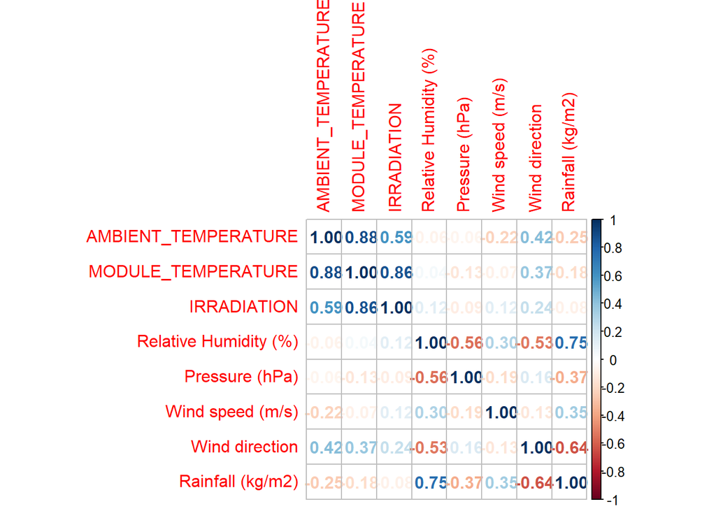

```r
M = cor(subset(linreg_daily_yield.dt, select = -c(DAILY_YIELD, SOURCE_KEY)))
corrplot(M, method = "number")
```

```r
# We discover that MODULE_TEMPERATURE is very highly correlated with both AMBIENT_TEMPERATURE and IRRADIATION, while `Relative Humidity (%)` and `Rainfall (kg/m2)` are also highly correlated


m1 <- lm(DAILY_YIELD ~ .-SOURCE_KEY, data = linreg_daily_yield.dt)
summary(m1)
```

```
##
## Call:
## lm(formula = DAILY_YIELD ~ . - SOURCE_KEY, data = linreg_daily_yield.dt)
##
## Residuals:
##      Min       1Q   Median       3Q      Max
## -3024.39  -179.25    40.78   284.81   997.58
##
## Coefficients:
##                           Estimate Std. Error t value Pr(>|t|)
## (Intercept)             43094.5478 13348.6686   3.228 0.001312 **
## AMBIENT_TEMPERATURE       393.3232    38.1820  10.301  < 2e-16 ***
## MODULE_TEMPERATURE       -336.6636    28.4521 -11.833  < 2e-16 ***
## IRRADIATION             22741.4325   854.6027  26.611  < 2e-16 ***
## `Relative Humidity (%)`    -6.0052     3.9732  -1.511 0.131196
## `Pressure (hPa)`          -42.8694    13.2830  -3.227 0.001317 **
## `Wind speed (m/s)`        160.7709    25.7530   6.243 8.08e-10 ***
## `Wind direction`           -1.3317     0.8216  -1.621 0.105550
## `Rainfall (kg/m2)`      -3219.5930   923.0747  -3.488 0.000522 ***
## ---
## Signif. codes:  0 '***' 0.001 '**' 0.01 '*' 0.05 '.' 0.1 ' ' 1
##
## Residual standard error: 432.8 on 607 degrees of freedom
## Multiple R-squared:  0.8128, Adjusted R-squared:  0.8104
## F-statistic: 329.5 on 8 and 607 DF,  p-value: < 2.2e-16
```

```r
vif(m1)
```

```
##     AMBIENT_TEMPERATURE      MODULE_TEMPERATURE             IRRADIATION
##               10.469496               27.605739                9.571620
## `Relative Humidity (%)`        `Pressure (hPa)`      `Wind speed (m/s)`
##                3.349840                1.633092                1.359730
##        `Wind direction`      `Rainfall (kg/m2)`
##                2.135852                3.067921
```

```r
# we see that MODULE_TEMPERATURE has the highest VIF value of 27.6 > 10, we try and exclude that first

m2 <- lm(DAILY_YIELD ~ .-SOURCE_KEY -MODULE_TEMPERATURE, data = linreg_daily_yield.dt)
summary(m2)
```

```
##
## Call:
## lm(formula = DAILY_YIELD ~ . - SOURCE_KEY - MODULE_TEMPERATURE,
##     data = linreg_daily_yield.dt)
##
## Residuals:
##      Min       1Q   Median       3Q      Max
## -2852.65  -249.82    73.06   308.75  1028.60
##
## Coefficients:
##                           Estimate Std. Error t value Pr(>|t|)
## (Intercept)              5057.0754 14360.7280   0.352  0.72485
## AMBIENT_TEMPERATURE       -11.8921    18.7161  -0.635  0.52541
## IRRADIATION             13618.2622   408.5870  33.330  < 2e-16 ***
## `Relative Humidity (%)`    -5.0976     4.4032  -1.158  0.24744
## `Pressure (hPa)`           -2.8614    14.2384  -0.201  0.84080
## `Wind speed (m/s)`        192.3315    28.3921   6.774 2.96e-11 ***
## `Wind direction`           -1.9345     0.9089  -2.128  0.03371 *
## `Rainfall (kg/m2)`      -3152.2531  1023.1524  -3.081  0.00216 **
## ---
## Signif. codes:  0 '***' 0.001 '**' 0.01 '*' 0.05 '.' 0.1 ' ' 1
##
## Residual standard error: 479.7 on 608 degrees of freedom
## Multiple R-squared:  0.7696, Adjusted R-squared:  0.767
## F-statistic: 290.2 on 7 and 608 DF,  p-value: < 2.2e-16
```

```r
vif(m2)
```

```
##     AMBIENT_TEMPERATURE             IRRADIATION `Relative Humidity (%)`
##                2.047462                1.780748                3.348591
##        `Pressure (hPa)`      `Wind speed (m/s)`        `Wind direction`
##                1.527277                1.345144                2.127641
##      `Rainfall (kg/m2)`
##                3.067804
```

```r
# now all the VIF values are <10



# With selected features, develop model on trainset
train <- sample.split(Y = linreg_daily_yield.dt$DAILY_YIELD, SplitRatio = 0.7)
trainset <- subset(linreg_daily_yield.dt, train == T)
testset <- subset(linreg_daily_yield.dt, train == F)

# Checking the distribution of Y is similar in trainset vs testset.
summary(trainset$DAILY_YIELD)
```

```
##    Min. 1st Qu.  Median    Mean 3rd Qu.    Max.
##    3958    6593    7451    7329    8128    9163
```

```r
summary(testset$DAILY_YIELD)
```

```
##    Min. 1st Qu.  Median    Mean 3rd Qu.    Max.
##    4998    6365    7289    7199    8007    8997
```

```r
# yes, similar enough

# create model
m3 <- lm(DAILY_YIELD ~ .-SOURCE_KEY -MODULE_TEMPERATURE, data = trainset)
summary(m3)
```

```
##
## Call:
## lm(formula = DAILY_YIELD ~ . - SOURCE_KEY - MODULE_TEMPERATURE,
##     data = trainset)
##
## Residuals:
##      Min       1Q   Median       3Q      Max
## -2791.39  -246.73    65.93   307.35   998.05
##
## Coefficients:
##                          Estimate Std. Error t value Pr(>|t|)
## (Intercept)              -333.565  17449.506  -0.019 0.984758
## AMBIENT_TEMPERATURE       -10.113     23.270  -0.435 0.664079
## IRRADIATION             13755.948    507.301  27.116  < 2e-16 ***
## `Relative Humidity (%)`    -1.850      5.327  -0.347 0.728560
## `Pressure (hPa)`            2.424     17.298   0.140 0.888618
## `Wind speed (m/s)`        172.928     35.251   4.906 1.33e-06 ***
## `Wind direction`           -2.144      1.113  -1.927 0.054611 .
## `Rainfall (kg/m2)`      -4329.595   1202.246  -3.601 0.000354 ***
## ---
## Signif. codes:  0 '***' 0.001 '**' 0.01 '*' 0.05 '.' 0.1 ' ' 1
##
## Residual standard error: 486.5 on 423 degrees of freedom
## Multiple R-squared:  0.7646, Adjusted R-squared:  0.7607
## F-statistic: 196.3 on 7 and 423 DF,  p-value: < 2.2e-16
```

```r
# residuals(m3)

# we see that AMBIENT_TEMPERATURE, `Relative Humidity (%)` and `Pressure (hPa)` are not statistically significant , we will create another model without these variables

m4 <- lm(DAILY_YIELD ~ .-SOURCE_KEY -MODULE_TEMPERATURE -AMBIENT_TEMPERATURE -`Relative Humidity (%)` -`Pressure (hPa)`, data = trainset)
summary(m4)
```

```
##
## Call:
## lm(formula = DAILY_YIELD ~ . - SOURCE_KEY - MODULE_TEMPERATURE -
##     AMBIENT_TEMPERATURE - `Relative Humidity (%)` - `Pressure (hPa)`,
##     data = trainset)
##
## Residuals:
##      Min       1Q   Median       3Q      Max
## -2773.78  -242.09    58.82   309.42  1015.78
##
## Coefficients:
##                     Estimate Std. Error t value Pr(>|t|)
## (Intercept)         1766.954    304.559   5.802 1.28e-08 ***
## IRRADIATION        13563.994    396.222  34.233  < 2e-16 ***
## `Wind speed (m/s)`   177.228     32.481   5.456 8.26e-08 ***
## `Wind direction`      -2.243      1.015  -2.211   0.0276 *
## `Rainfall (kg/m2)` -4700.385    949.684  -4.949 1.07e-06 ***
## ---
## Signif. codes:  0 '***' 0.001 '**' 0.01 '*' 0.05 '.' 0.1 ' ' 1
##
## Residual standard error: 485 on 426 degrees of freedom
## Multiple R-squared:  0.7643, Adjusted R-squared:  0.7621
## F-statistic: 345.4 on 4 and 426 DF,  p-value: < 2.2e-16
```

```r
# residuals(m4)

# Residuals = Error = Actual - Model Predicted
RMSE.m4.train <- sqrt(mean(residuals(m4)^2))  # RMSE on trainset based on m4 model.
summary(abs(residuals(m4)))  # Check Min Abs Error and Max Abs Error.
```

```
##     Min.  1st Qu.   Median     Mean  3rd Qu.     Max.
##    1.053  122.464  275.748  339.666  455.103 2773.783
```

```r
# Apply model from trainset to predict on testset.
predict.m4.test <- predict(m4, newdata = testset)
testset.error <- testset$DAILY_YIELD - predict.m4.test

# Testset Errors
RMSE.m4.test <- sqrt(mean(testset.error^2))
summary(abs(testset.error))
```

```
##    Min. 1st Qu.  Median    Mean 3rd Qu.    Max.
##    4.81  150.37  291.97  365.75  498.00 1671.72
```

```r
# mean testset error is 365.75
```

# Check by individual SOURCE_KEY

The full datasets consists of many panels, and when different data are brought together, it might display some characteristics that were otherwise not present. We will look at each of the panels individually to see if we find anything interesting

```r
for (level in levels(linreg_daily_yield.dt$SOURCE_KEY)) {
  source_key_DAILY_YIELD.dt <- filter(linreg_daily_yield.dt, SOURCE_KEY==level) %>%
    subset(, -c(SOURCE_KEY))

  m5 <- lm(DAILY_YIELD ~ . -MODULE_TEMPERATURE, data = source_key_DAILY_YIELD.dt)
  paste("levels: ", as.character(level))
  print(summary(m5))
  print(vif(m5))
}
```

```
##
## Call:
## lm(formula = DAILY_YIELD ~ . - MODULE_TEMPERATURE, data = source_key_DAILY_YIELD.dt)
##
## Residuals:
##     Min      1Q  Median      3Q     Max
## -710.32 -187.84  -56.15  204.74  803.61
##
## Coefficients:
##                           Estimate Std. Error t value Pr(>|t|)
## (Intercept)             -30182.261  56175.472  -0.537    0.597
## AMBIENT_TEMPERATURE         41.215     73.187   0.563    0.580
## IRRADIATION              12360.673   1732.797   7.133 6.54e-07 ***
## `Relative Humidity (%)`     21.437     17.410   1.231    0.232
## `Pressure (hPa)`            30.316     55.673   0.545    0.592
## `Wind speed (m/s)`         116.546    110.789   1.052    0.305
## `Wind direction`            -2.728      3.439  -0.793    0.437
## `Rainfall (kg/m2)`      -22759.932   4080.407  -5.578 1.85e-05 ***
## ---
## Signif. codes:  0 '***' 0.001 '**' 0.01 '*' 0.05 '.' 0.1 ' ' 1
##
## Residual standard error: 396.4 on 20 degrees of freedom
## Multiple R-squared:  0.9002, Adjusted R-squared:  0.8652
## F-statistic: 25.76 on 7 and 20 DF,  p-value: 1.1e-08
##
##     AMBIENT_TEMPERATURE             IRRADIATION `Relative Humidity (%)`
##                2.064989                1.854952                3.425681
##        `Pressure (hPa)`      `Wind speed (m/s)`        `Wind direction`
##                1.549405                1.375498                2.057781
##      `Rainfall (kg/m2)`
##                3.218139
##
## Call:
## lm(formula = DAILY_YIELD ~ . - MODULE_TEMPERATURE, data = source_key_DAILY_YIELD.dt)
##
## Residuals:
##      Min       1Q   Median       3Q      Max
## -1431.96  -163.13    35.35   268.25   990.94
##
## Coefficients:
```

[output cut: 627 more lines]

```
## `Wind direction`        -6.212e-01  3.417e+00  -0.182   0.8576
## `Rainfall (kg/m2)`      -2.685e+02  3.758e+03  -0.071   0.9437
## ---
## Signif. codes:  0 '***' 0.001 '**' 0.01 '*' 0.05 '.' 0.1 ' ' 1
##
## Residual standard error: 382.9 on 20 degrees of freedom
## Multiple R-squared:  0.8859, Adjusted R-squared:  0.846
## F-statistic: 22.18 on 7 and 20 DF,  p-value: 4.036e-08
##
##     AMBIENT_TEMPERATURE             IRRADIATION `Relative Humidity (%)`
##                2.093192                1.827238                3.282376
##        `Pressure (hPa)`      `Wind speed (m/s)`        `Wind direction`
##                1.513106                1.348634                2.143324
##      `Rainfall (kg/m2)`
##                2.973533
```